# HAR Machine Learning Project

Ojustwin Naik

August 21, 2015

# Background

Using devices such as Jawbone Up, Nike FuelBand, and Fitbit it is now possible to collect a large amount of data about personal activity relatively inexpensively. These type of devices are part of the quantified self movement – a group of enthusiasts who take measurements about themselves regularly to improve their health, to find patterns in their behavior, or because they are tech geeks. One thing that people regularly do is quantify how much of a particular activity they do, but they rarely quantify how well they do it. In a project led by Velloso, E.; Bulling, A.; Gellersen, H.; Ugulino, W.; Fuks, H. data from accelerometers on the belt, forearm, arm, and dumbell of 6 participants was collected to investigate “how (well)” an activity was performed by the wearer. They were asked to perform barbell lifts correctly and incorrectly in 5 different ways. More information is available from the website here: http://groupware.les.inf.puc-rio.br/har (see the section on the Weight Lifting Exercise Dataset).

# Objective

The objective of this report is to use the data from the study by Velloso et al. and train a machine learning algorithm that can predict 20 different test cases by classifying each into the following classes: exercise performed exactly according to the specification (Class A), throwing the elbows to the front (Class B), lifting the dumbbell only halfway (Class C), lowering the dumbbell only halfway (Class D) and throwing the hips.

# Summary

Given the limitations, the best predictive model for classifying the quality of the exercise using the HAR data was built using the Random Forest algorithm. There were significant limitations that influenced the study. The biggest being that the missing summary stats data could not be used as part of the model training. In the original study the summary stats played a big role in the classification algorithm. Furthermore, there were a limited number of algorithms tested in this study. There were some other algorithms such as Bagged CART that were also promising but were not as fast or accurate as the Random Forest.

# Data

The training data for this project are available here: https://d396qusza40orc.cloudfront.net/predmachlearn/pml-training.csv

The test data are available here: https://d396qusza40orc.cloudfront.net/predmachlearn/pml-testing.csv

## Read in files

Set working directory with CSV files.

```r
training <- read.csv("pml-training.csv", na.strings=c("NA","DIV/0",""))
testing <- read.csv("pml-testing.csv", na.strings=c("NA","DIV/0",""))
```

# Preprocessing

After studying the data, any variables that were mostly NA, Div0 or nulls were selected for removal. Most of these NA variables were summary stats which will are not expected to be available in the test data. Furthermore, date/time, subject, new_window, and num_window variables were also selected for removal as they will have no meaningful relationship to the prediction of the outcome variable.

```r
training <- training[, colSums(is.na(training))==0]
testing <- testing[, colSums(is.na(testing))==0]

training <- training[, -which(names(training) %in% c("user_name","raw_timestamp_part_1", "raw_timestamp_part_2", "cvtd_timestamp", "new_window","num_window"))]
testing <- testing[, -which(names(testing) %in% c("user_name","raw_timestamp_part_1", "raw_timestamp_part_2", "cvtd_timestamp", "new_window","num_window"))]

training <- training[,-c(1)]
testing <- testing[,-c(1)]
```

After cleaning the resulting dataset does not have any predictors of Factor type that need to be converted. Also no near zero variance variables or highly correlated variables were found in the cleaned data set.

The cleaned training set contains of 19622 obs. of 53 variables.

# Data Splitting

The training data set was partitioned into two sub data sets, 60% for training and 40% for testing.

```r
inTraining <- createDataPartition(training$classe, p = .60, list = FALSE)
mTrain <- training[ inTraining,]
mTest  <- training[-inTraining,]
```

The partitioned training set contains of 11776 obs. of 53 variables.

# Model Training and Tuning

## Quick and dirty model comparision

The following machine learning algorithms were tested against a small sample of the data (1000 observations), out of which only 3 (BCART, GBM, RF) showed accuracy over 80%.

```r
#Use a small sample data set for quick train
mTrain.smp <- sample_n(mTrain, 1000)
set.seed(777)
#Bagged CART
modFit.BCART <- train(classe~.,data=mTrain.smp, method="treebag")
set.seed(777)
#Stochastic Gradient Boosting
modFit.GBM <- train(classe~.,data=mTrain.smp, method="gbm")
set.seed(777)
#Gaussian Process with Radial Basis Function Kernel
modFit.GPR <- train(classe~.,data=mTrain.smp, method="gaussprRadial")
set.seed(777)
#K-Nearest Neighbors
modFit.KNN <- train(classe~.,data=mTrain.smp, method="knn")
set.seed(777)
#Naive Bayes
modFit.NB <- train(classe~.,data=mTrain.smp, method="nb")
set.seed(777)
#Neural Networks
modFit.NN <- train(classe~.,data=mTrain.smp, method="nnet")
set.seed(777)
#Random Forest
modFit.RF <- train(classe~.,data=mTrain.smp, method="rf")
set.seed(777)
#Support Vector Machines with Polynomial Kernel
modFit.SVMP <- train(classe~.,data=mTrain.smp, method="svmPoly")
```

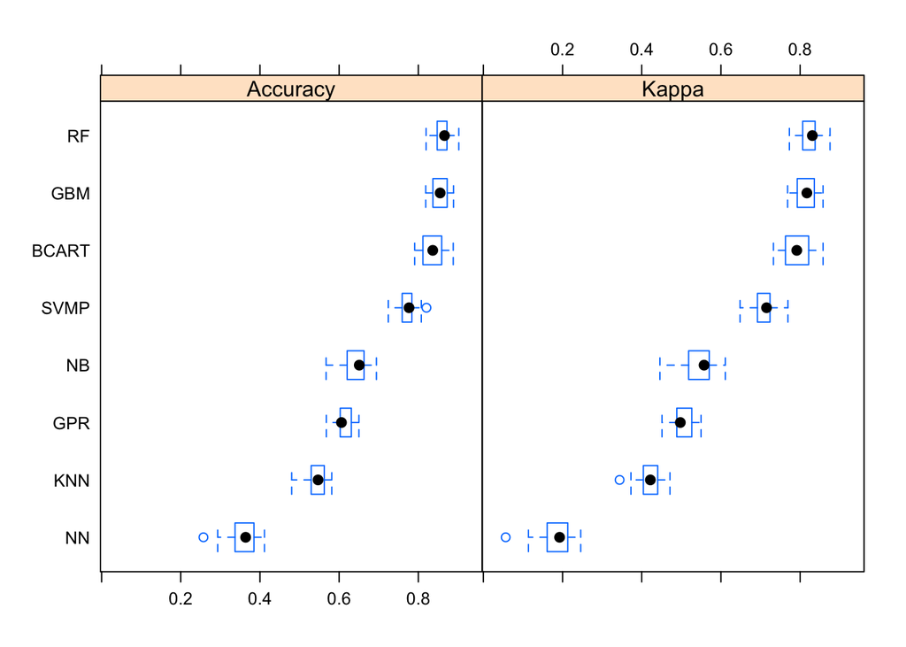

```r
# collect resamples
results <- resamples(list(GPR=modFit.GPR, KNN=modFit.KNN, SVMP=modFit.SVMP, GBM=modFit.GBM, BCART=modFit.BCART, NB=modFit.NB, NN=modFit.NN, RF=modFit.RF))
#summary(results)
bwplot(results)
```

## Detailed Model Comparison

Each of the 3 highest performing models from the quick comparison were then trained against the partitioned training *sub data set* while using K-Folds cross validation for tuning.

```r
#K-fold subsampling was used for cross validation with K=10
fitControl <- trainControl(method = "repeatedcv", number = 10, repeats = 3)

#Random Forest
set.seed(777)
fit.RF <- train(classe~.,data=mTrain, trControl = fitControl, method="rf")
saveRDS(fit.RF, file="fitRF.rds")

#Stochastic Gradient Boosting
set.seed(777)
fit.GBM <- train(classe~.,data=mTrain, trControl = fitControl, method="gbm")
saveRDS(fit.GBM, file="fitGBM.rds")

#Bagged CART
set.seed(777)
fit.BCART <- train(classe~.,data=mTrain, trControl = fitControl, method="treebag")
saveRDS(fit.BCART, file="fitBCART.rds")
```

```r
# collect resamples
fitResults <- resamples(list(RF=fit.RF, GBM=fit.GBM, BCART=fit.BCART))
# summarize the distributions
summary(fitResults)
```

```
##
## Call:
## summary.resamples(object = fitResults)
##
## Models: RF, GBM, BCART
## Number of resamples: 30
##
## Accuracy
##         Min. 1st Qu. Median   Mean 3rd Qu.   Max. NA's
## RF    0.9839  0.9890 0.9902 0.9900  0.9915 0.9949    0
## GBM   0.9508  0.9573 0.9631 0.9625  0.9652 0.9805    0
## BCART 0.9703  0.9787 0.9796 0.9797  0.9822 0.9881    0
##
## Kappa
##         Min. 1st Qu. Median   Mean 3rd Qu.   Max. NA's
## RF    0.9796  0.9860 0.9876 0.9874  0.9893 0.9935    0
## GBM   0.9377  0.9460 0.9533 0.9525  0.9560 0.9753    0
## BCART 0.9624  0.9731 0.9742 0.9744  0.9775 0.9850    0
```

Again based on Accuracy and Kappa the Random Forest model is most promising.

## Test Model Predictions with hold out test data set for validation

```r
predictRF <- predict(fit.RF, newdata = mTest)
confusionMatrix(predictRF, mTest$classe)
```

```
## Confusion Matrix and Statistics
##
##           Reference
## Prediction    A    B    C    D    E
##          A 2231    2    0    0    0
##          B    1 1510    5    0    0
##          C    0    6 1363   10    0
##          D    0    0    0 1275    2
##          E    0    0    0    1 1440
##
## Overall Statistics
##
##                Accuracy : 0.9966
##                  95% CI : (0.995, 0.9977)
##     No Information Rate : 0.2845
##     P-Value [Acc > NIR] : < 2.2e-16
##
##                   Kappa : 0.9956
##  Mcnemar's Test P-Value : NA
##
## Statistics by Class:
##
##                      Class: A Class: B Class: C Class: D Class: E
## Sensitivity            0.9996   0.9947   0.9963   0.9914   0.9986
## Specificity            0.9996   0.9991   0.9975   0.9997   0.9998
## Pos Pred Value         0.9991   0.9960   0.9884   0.9984   0.9993
## Neg Pred Value         0.9998   0.9987   0.9992   0.9983   0.9997
## Prevalence             0.2845   0.1935   0.1744   0.1639   0.1838
## Detection Rate         0.2843   0.1925   0.1737   0.1625   0.1835
## Detection Prevalence   0.2846   0.1932   0.1758   0.1628   0.1837
## Balanced Accuracy      0.9996   0.9969   0.9969   0.9956   0.9992
```

```r
predictGBM <- predict(fit.GBM, newdata = mTest)
#confusionMatrix(predictGBM, mTest$classe)

predictBCART <- predict(fit.BCART, newdata = mTest)
#confusionMatrix(predictBCART, mTest$classe)
```

Below are plots comparing the performance of the 3 models.

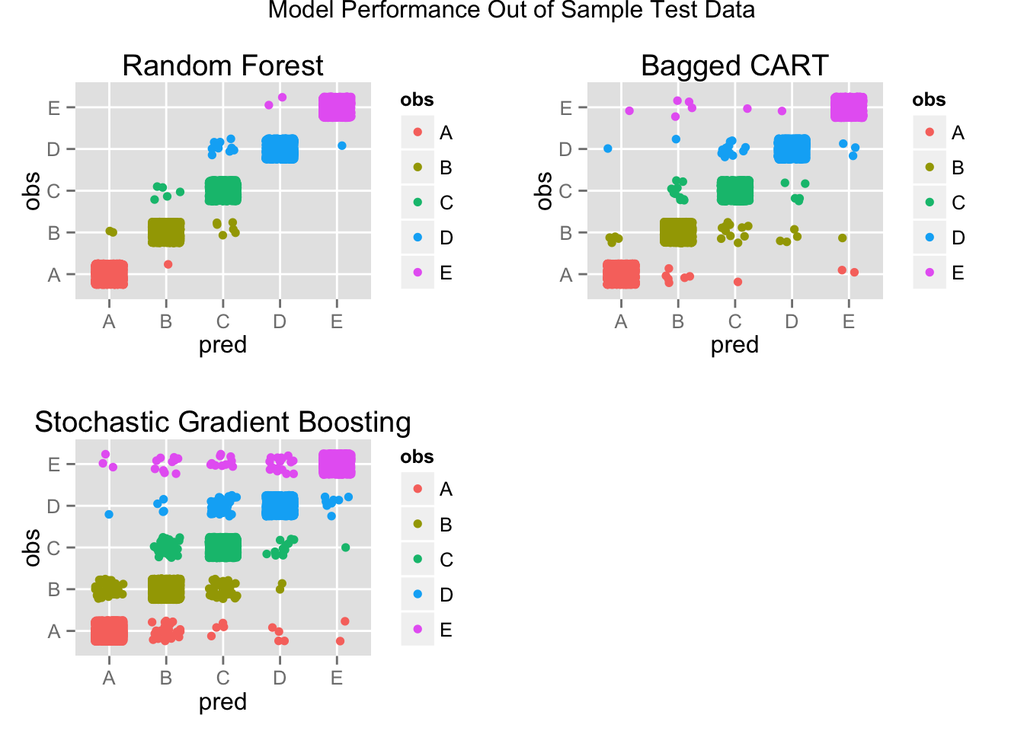

# Model Test

Run the model against the separate test data with 20 observations.

```r
predictRF.test <- predict(fit.RF, newdata = testing)
predictRF.test
```

```
##  [1] B A B A A E D B A A B C B A E E A B B B
## Levels: A B C D E
```